# Week 2 Intro to Tidyverse

Rachel Saidi

August 19, 2019

# Load Data from Three Different Sources

In the following notes, you will load data directly from a URL, directly from pre-build datasets in R, and finally from a file you save in your own folder.

## Load Data from a URL

You can load data from a folder or you can load data directly from a URL. The next example loads the dataset, “Test Scores”, directly from the URL where it resides.

```r
# install.packages("tidyverse")
getwd()
```

```
## [1] "/home/dutky/mcData110"
```

```r
library(tidyverse)
allscores <- readr::read_csv("https://goo.gl/MJyzNs")
dim(allscores)
```

```
## [1] 22  4
```

Notice R interprets the variable “group” as continuous values (col_double). We will fix this later. The command “dim” provides the dimensions of the data, which are 22 observations (rows) by 4 variables (columns).

## Use Side-by-Side Boxplots

Here is some easy code to create 3 groups of boxplots with some easy-to-access data, filled by group. Since the groups are discrete, you can get rid of the shading.

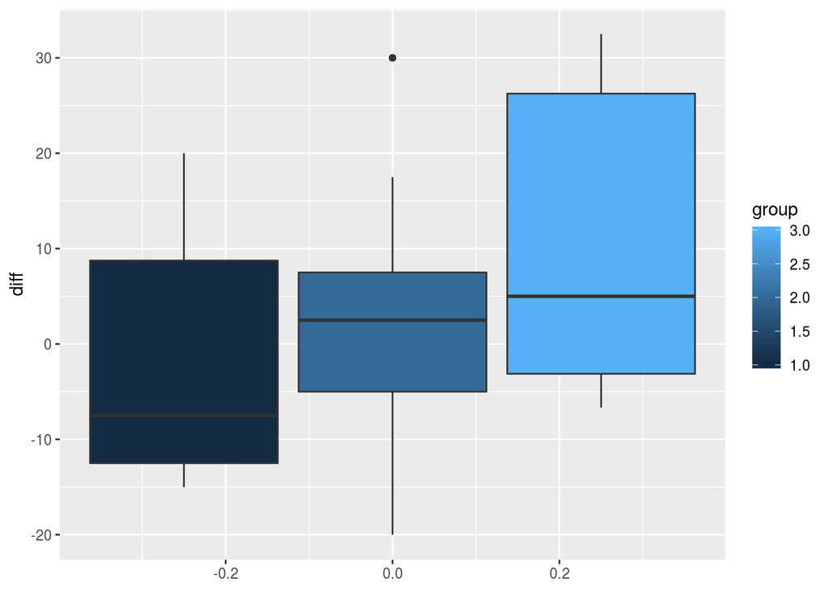

```r
boxpl <- allscores %>% ggplot() + geom_boxplot(aes(y=diff, group=group,
                                                fill=group))
boxpl
```

Notice that the legend give a continuous range of values for the scores, even though the scores are only 1, 2, or 3. The code guides(fill = FALSE) will get rid of the legend.

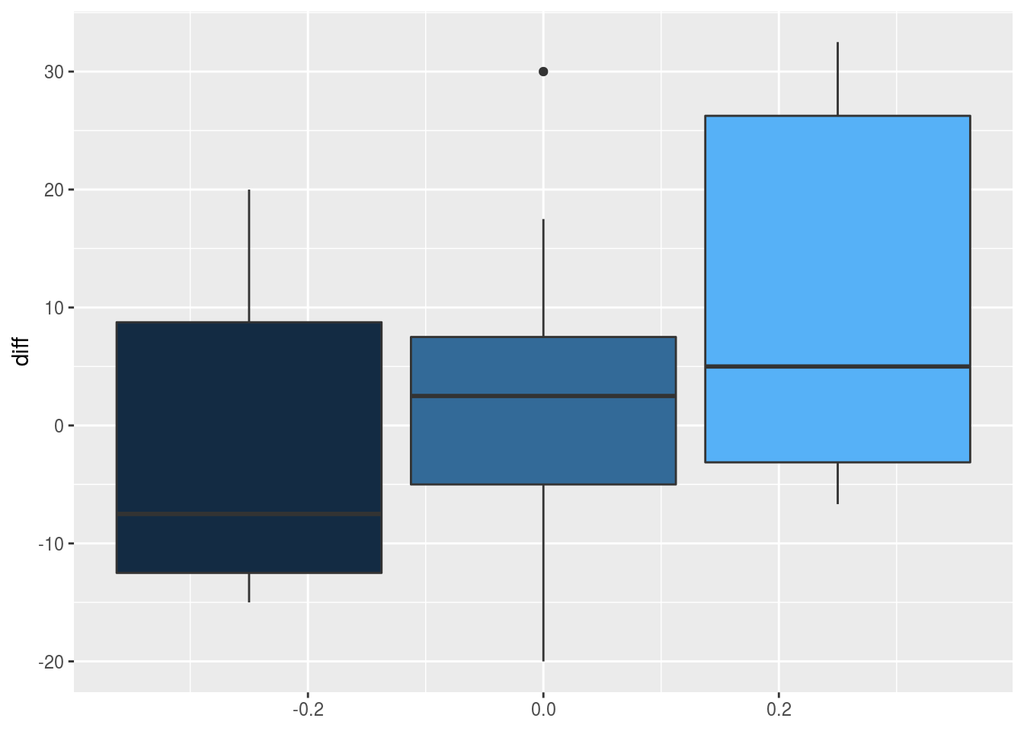

```r
boxpl2 <- boxpl + guides(fill=FALSE)
boxpl2
```

Ensure that the groups are considered as factors, rather than numbers. Then manually fill with the 3 colors: white, light gray, and dark gray. Make the boxplots orient horizontally.

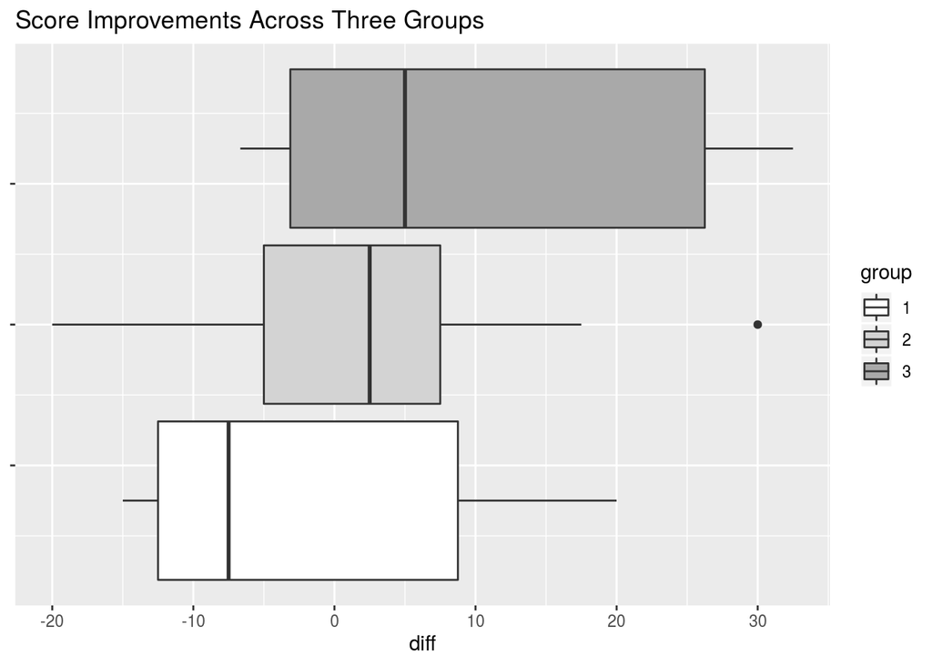

```r
allscores %>%
  mutate(group=factor(group, levels=c("1","2","3"), ordered=TRUE)) %>%
  ggplot() + geom_boxplot(aes(y=diff, group=group, fill=group)) +
  scale_fill_manual(values=c("white","lightgray","darkgray")) +
  theme(axis.text.y=element_blank()) +
  ggtitle("Score Improvements Across Three Groups") +
  coord_flip()
```

## Load Built in Data from R

Some data frames are built in to R, such as mpg. Load the data, then use str and head to look at the data.

{r mpg} loads the data. Alternatively, you can use the command: load(“mpg”)

You will look at the data using the command “str” (gives the structure of the data), “head” (lists the first 6 rows of observations in the dataset), and “describe” from the “psych” package (gives quite detailed summary statistics on the continuous variables).

```r
# {r mpg, warning = FALSE}
# install.packages("tidyverse")
# install.packages("psych")
library(tidyverse)
library(psych)
str(mpg)
```

```
## Classes 'tbl_df', 'tbl' and 'data.frame':    234 obs. of  11 variables:
##  $ manufacturer: chr  "audi" "audi" "audi" "audi" ...
##  $ model       : chr  "a4" "a4" "a4" "a4" ...
##  $ displ       : num  1.8 1.8 2 2 2.8 2.8 3.1 1.8 1.8 2 ...
##  $ year        : int  1999 1999 2008 2008 1999 1999 2008 1999 1999 2008 ...
##  $ cyl         : int  4 4 4 4 6 6 6 4 4 4 ...
##  $ trans       : chr  "auto(l5)" "manual(m5)" "manual(m6)" "auto(av)" ...
##  $ drv         : chr  "f" "f" "f" "f" ...
##  $ cty         : int  18 21 20 21 16 18 18 18 16 20 ...
##  $ hwy         : int  29 29 31 30 26 26 27 26 25 28 ...
##  $ fl          : chr  "p" "p" "p" "p" ...
##  $ class       : chr  "compact" "compact" "compact" "compact" ...
```

```r
head(mpg)
```

```
## # A tibble: 6 x 11
##   manufacturer model displ  year   cyl trans  drv     cty   hwy fl    class
##   <chr>        <chr> <dbl> <int> <int> <chr>  <chr> <int> <int> <chr> <chr>
## 1 audi         a4      1.8  1999     4 auto(… f        18    29 p     comp…
## 2 audi         a4      1.8  1999     4 manua… f        21    29 p     comp…
## 3 audi         a4      2    2008     4 manua… f        20    31 p     comp…
## 4 audi         a4      2    2008     4 auto(… f        21    30 p     comp…
## 5 audi         a4      2.8  1999     6 auto(… f        16    26 p     comp…
## 6 audi         a4      2.8  1999     6 manua… f        18    26 p     comp…
```

```r
describe(mpg)
```

```
##               vars   n    mean   sd median trimmed  mad    min  max range
## manufacturer*    1 234     NaN   NA     NA     NaN   NA    Inf -Inf  -Inf
## model*           2 234     NaN   NA     NA     NaN   NA    Inf -Inf  -Inf
## displ            3 234    3.47 1.29    3.3    3.39 1.33    1.6    7   5.4
## year             4 234 2003.50 4.51 2003.5 2003.50 6.67 1999.0 2008   9.0
## cyl              5 234    5.89 1.61    6.0    5.86 2.97    4.0    8   4.0
## trans*           6 234     NaN   NA     NA     NaN   NA    Inf -Inf  -Inf
## drv*             7 234    4.00 0.00    4.0    4.00 0.00    4.0    4   0.0
## cty              8 234   16.86 4.26   17.0   16.61 4.45    9.0   35  26.0
## hwy              9 234   23.44 5.95   24.0   23.23 7.41   12.0   44  32.0
## fl*             10 234     NaN   NA     NA     NaN   NA    Inf -Inf  -Inf
## class*          11 234     NaN   NA     NA     NaN   NA    Inf -Inf  -Inf
##               skew kurtosis   se
## manufacturer*   NA       NA   NA
## model*          NA       NA   NA
## displ         0.44    -0.91 0.08
## year          0.00    -2.01 0.29
## cyl           0.11    -1.46 0.11
## trans*          NA       NA   NA
## drv*           NaN      NaN 0.00
## cty           0.79     1.43 0.28
## hwy           0.36     0.14 0.39
## fl*             NA       NA   NA
## class*          NA       NA   NA
```

It is essential to recognize that variables may be: int (integer), num (numeric), or double vs char (character) and factor (for categories)

Typically, chr or factor are used for discrete variables and int, dbl, or num for continuous variables.

## Introducing ggplot2 and the grammar of graphics

The “gg” in ggplot2 stands for “grammar of graphics,” an approach to drawing charts devised by the statistician Leland Wilkinson. Rather than thinking in terms of finished charts like a scatter plot or a column chart, it starts by defining the coordinate system (usually the X and Y axes of a cartesian system), maps data onto those coordinates, and then adds layers such as points, bars and so on. This is the logic behind ggplot2 code.

Some key things to understand about ggplot2:

. ggplot This is the master function that creates a ggplot2 chart.

. aes This function, named for “aesthetic mapping,” is used whenever data values are mapped onto a chart. So it is used when you define which variables are plotted onto the X and Y axes, and also if you want to change the size or color of parts of the chart according to values for a variable.

. geom All of the functions that add layers to a chart start with geom, followed by an underscore, for example geom_point() or geom_bar(). The code in the brackets for any geom layer styles the items in that layer, and can include aes mappings of values from data.

. theme This function modifies the appearance of elements of a plot, used, for example, to set size and font face for text, the position of a legend, and so on.

. scale Functions that begin with scale, followed by an underscore, are used to modify the way an aes mapping of data appears on a chart. They can change the axis range, for example, or specify a color palette to be used to encode values in the data.

. + is used each time you add a layer, a scale, a theme, or elements like axis labels and a title After a + you can continue on the same line of code or move the next line. I usually write a new line after each +, which makes the code easier to follow.

## Now make a scatterplot using ggplot2

Make a scatterplot of city vs highway miles per gallon, but sort/color points by either 4-wheel, front-wheel, or rear-wheel drive

Here is how we will code:

1. name the plot: “plot1” <-
2. call back the name of the dataset “mpg” and “pipe it” (more on that later) to create the frame for your plot
3. call “ggplot” to make a set of axes, with the aesthetics (aes) for city and highway mpg, but color points by the factors for drv
4. add geom_point to see the points
5. call plot1 to see the entire plot

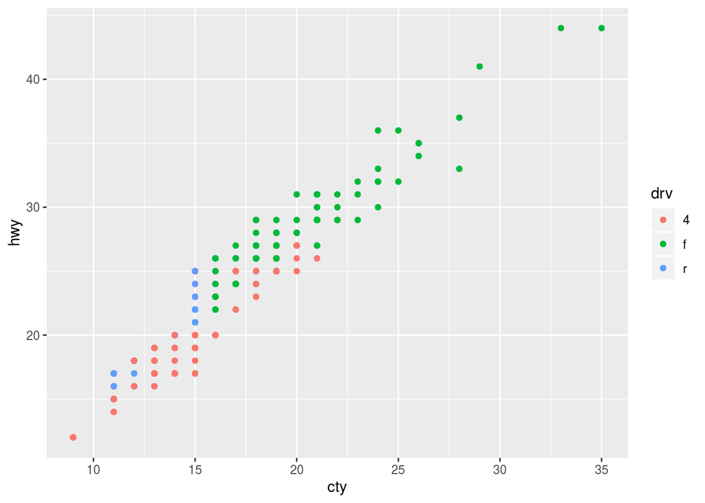

```r
plot1 <- mpg %>% ggplot(aes(cty, hwy, color = drv))+
  geom_point()
plot1
```

Notice that the blue points for rear-wheel drive are only at the lower left side of the plot (i.e., not great mpg). Red points for 4-wheel drive have a wider spread of points, but they are also mainly at the lower left corner of the plot. The green points for front-wheel drive are mostly at the upper right, for the higher mpg.

## Add a title and labels

Although there are already axes labels, we can do better. We should also add a title

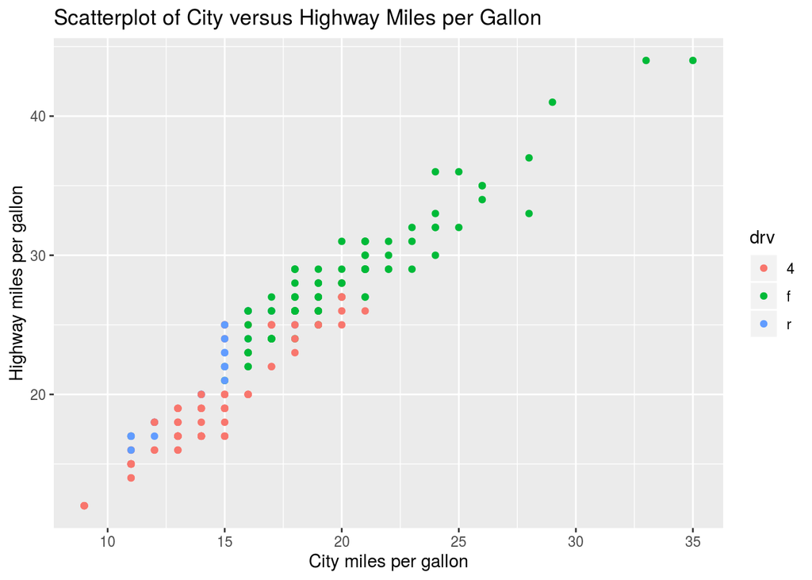

```r
plot1 <- mpg %>% ggplot(aes(cty, hwy, color = drv))+
  geom_point()+
  xlab("City miles per gallon") +
  ylab("Highway miles per gallon") +
  ggtitle("Scatterplot of City versus Highway Miles per Gallon")
plot1
```

## Clean data headings and variable names

Very soon, you will find data from other sources. The data will require some cleaning. Here are some important points to check: 1. Be sure the format is .csv 2. Be sure there are no spaces between variable names (headers). 3. Set all variable names to lowercase so you do not have to keep track of capitalizing.

Download this dataset, Household_debt, from http://bit.ly/2P3084E and save it in your dataset folder. Change your working directory to load the dataset from YOUR folder. Then run this code.

```r
#setwd("C:/Users/rsaidi/Dropbox/Rachel/MontColl/Datasets/Datasets")
household <- read_csv("household_debt.csv")
```

### Make all headings (column names) lowercase. Then remove all spaces between words in headings and replace them with underscores. Then look at it with “head”.

```r
names(household) <- tolower(names(household))
names(household) <- gsub(" ","_",names(household))
head(household)
```

```
## # A tibble: 6 x 8
##   period mortgage he_revolving auto_loan credit_card student_loan other
##   <chr>     <dbl>        <dbl>     <dbl>       <dbl>        <dbl> <dbl>
## 1 03:Q1      4.94         0.24      0.64        0.69         0.24  0.48
## 2 03:Q2      5.08         0.26      0.62        0.69         0.24  0.49
## 3 03:Q3      5.18         0.27      0.68        0.69         0.25  0.48
## 4 03:Q4      5.66         0.3       0.7         0.7          0.25  0.45
## 5 04:Q1      5.84         0.33      0.72        0.7          0.26  0.45
## 6 04:Q2      5.97         0.37      0.74        0.7          0.26  0.42
## # … with 1 more variable: total <dbl>
```